# Assignment 4: Spatial Predictive Analysis

Predictive Spatial Modeling for 311 Service Requests in Chicago

Author

Henry Sywulak-Herr

Published

December 8, 2025

Load Packages & Set Seed

```r
library(pacman)
p_load(tidyverse, sf, viridis, terra, spdep, FNN, MASS, spatstat.geom, spatstat.explore,
       viridis, patchwork, knitr, kableExtra, classInt)

set.seed(1234)
```

## Introduction

This analysis will create a spatial predictive model for burglaries in Chicago, IL based on 311 calls that report the locations of vacant and/or abandoned buildings. The hypothesis behind this 311 call category choice is that reports of vacant buildings could indicate areas of the city that are in poor repair (broken lighting, poor street cleaning/maintenance, etc.) and with less functional surveillance equipment in the area. Please note that there are inherent biases in the use of 311 call data. For example, calls might be less likely to be made by marginalized communities who have been historically persecuted by law enforcement compared to more white, affluent communities. Furthermore, knowledge of how to make 311 calls or what the system’s intended purpose is might not be equally distributed across Chicago, leading to a spatial imbalance of calls across the region.

## Part 1: Data Loading & Exploration

```r
# Load police districts (used for spatial cross-validation)
policeDistricts <-
  st_read("https://data.cityofchicago.org/api/geospatial/24zt-jpfn?method=export&format=GeoJSON", quiet = T) %>%
  st_transform('ESRI:102271') %>%
  dplyr::select(District = dist_num)

# Load police beats (smaller administrative units)
policeBeats <-
  st_read("https://data.cityofchicago.org/api/geospatial/n9it-hstw?method=export&format=GeoJSON", quiet = T) %>%
  st_transform('ESRI:102271') %>%
  dplyr::select(Beat = beat_num)

# Load Chicago boundary
chicagoBoundary <-
  st_read("https://raw.githubusercontent.com/urbanSpatial/Public-Policy-Analytics-Landing/master/DATA/Chapter5/chicagoBoundary.geojson", quiet = T) %>%
  st_transform('ESRI:102271')
```

Load burglaries data:

```r
burglaries <- st_read("./data/burglaries.shp", quiet = T) %>%
  st_transform('ESRI:102271')

# filter out 2018 burglaries to isolate 2017 data (no other years present)
# spatially filter to those within Chicago's boundary
burglaries_2017 <- burglaries %>%
  filter(year(Date) != 2018) %>%
  st_filter(chicagoBoundary, .predicate = st_within)

cat("Number of Burglaries:", nrow(burglaries_2017))
```

```
Number of Burglaries: 7455
```

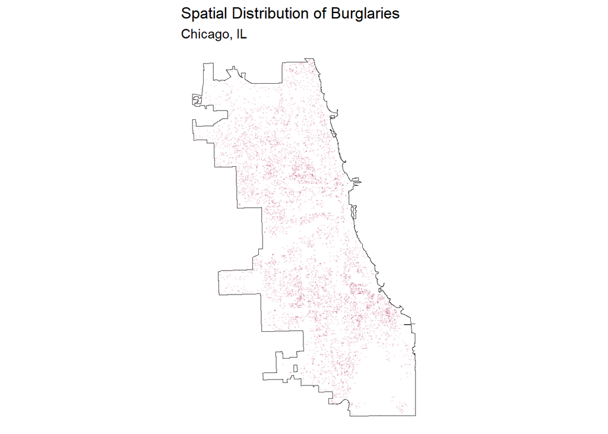

```r
ggplot() +
  geom_sf(data = chicagoBoundary, color = "grey20", fill = "transparent") +
  geom_sf(data = burglaries_2017, color = "maroon", size = 0.25, alpha = 0.1) +
  labs(title = "Spatial Distribution of Burglaries",
       subtitle = "Chicago, IL") +
  theme_void()
```

Load 311 Vacant and/or Abandoned Building reports. This dataset will be referred to as “Vacant Building Reports” for the remainder of this report:

```r
reports <- read_csv("./data/Vacant_and_Abandoned_Buildings_Reported.csv", show_col_types = F)

# filter out only 2017 reports
reports_2017 <- reports %>%
  filter(endsWith(`DATE SERVICE REQUEST WAS RECEIVED`, "2017"))

# filter out 2018 reports for later
reports_2018 <- reports %>%
  filter(endsWith(`DATE SERVICE REQUEST WAS RECEIVED`, "2018"))
```

```r
# remove rows without coordinate data and create a spatial point sf of the reports df
# filter dataset to the extent of Chicago's boundary
reports_2017_sf <- reports_2017 %>%
  filter(!is.na(LATITUDE) & !is.na(LONGITUDE)) %>%
  st_as_sf(coords = c("LONGITUDE", "LATITUDE"),
           crs = 4326) %>%
  st_transform("ESRI:102271") %>%
  st_filter(chicagoBoundary, .predicate = st_within)

# filter dataset to the extent of Chicago's boundary
reports_2018_sf <- reports_2018 %>%
  filter(!is.na(LATITUDE) & !is.na(LONGITUDE)) %>%
  st_as_sf(coords = c("LONGITUDE", "LATITUDE"),
           crs = 4326) %>%
  st_transform("ESRI:102271") %>%
  st_filter(chicagoBoundary, .predicate = st_within)

cat("Number of Reports of Vacant/Abandoned Buildings (2017):", nrow(reports_2017_sf), "\n\n")
```

```
Number of Reports of Vacant/Abandoned Buildings (2017): 3649
```

```r
cat("Number of Reports of Vacant/Abandoned Buildings (2018):", nrow(reports_2018_sf))
```

```
Number of Reports of Vacant/Abandoned Buildings (2018): 3842
```

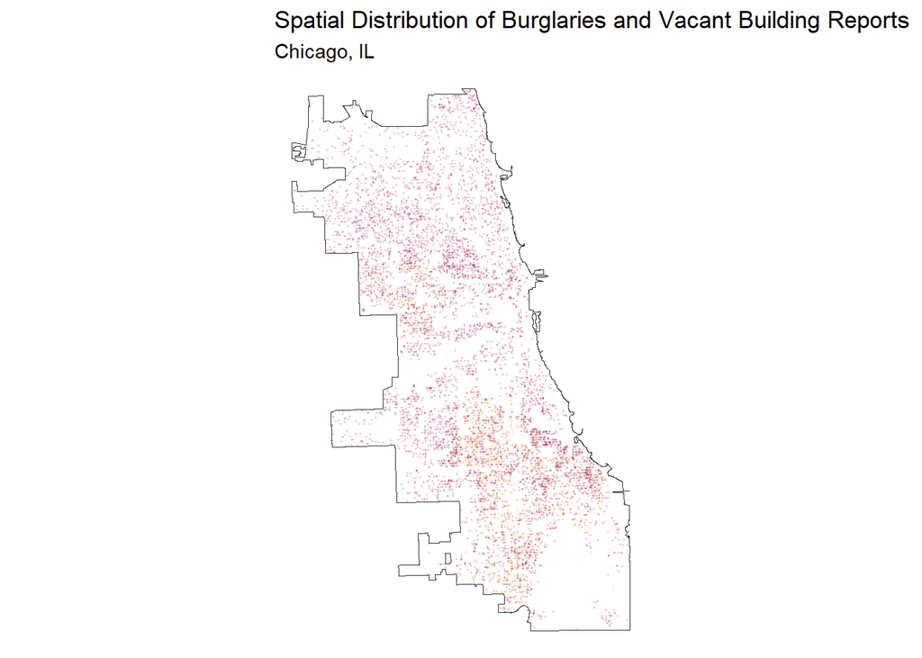

```r
ggplot() +
  geom_sf(data = chicagoBoundary, color = "grey20", fill = "transparent") +
  geom_sf(data = reports_2017_sf, color = "orange", size = 0.1, alpha = 0.1) +
  geom_sf(data = burglaries_2017, color = "maroon", size = 0.25, alpha = 0.2) +
  labs(title = "Spatial Distribution of Burglaries and Vacant Building Reports",
       subtitle = "Chicago, IL") +
  theme_void()
```

Visually, burglaries seem to be spatially correlated to the locations of vacant building reports. However, the extent of these reports seems to extend beyond the greatest concentrations of burglaries, which could influence the model later on.

## Part 2: Fishnet Grid Creation

```r
# create a 500x500m fishnet based on the chicago boundary
fishnet <- st_make_grid(chicagoBoundary,
                        cellsize = 500,
                        square = T) %>%
  st_as_sf() %>%
  mutate(fish_id = row_number()) %>%
  rename(geometry = x) %>%
  st_as_sf() %>%
  st_filter(chicagoBoundary, .predicate = st_intersects)
```

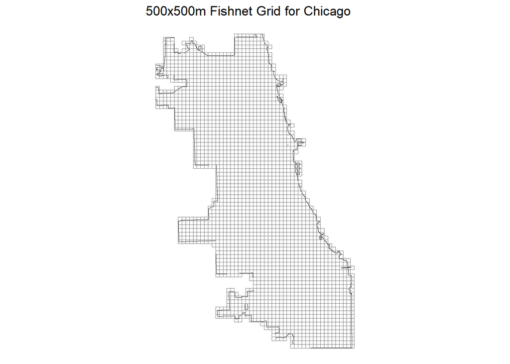

```r
ggplot() +
  geom_sf(data = chicagoBoundary, color = "grey20", fill = "transparent") +
  geom_sf(data = fishnet, color = "grey50", fill = "transparent") +
  labs(title = "500x500m Fishnet Grid for Chicago") +
  theme_void()
```

Now that a fishnet has been created, we can aggregate burglaries and vacant building reports to them, visualize them more effectively and model their correlation with burglaries.

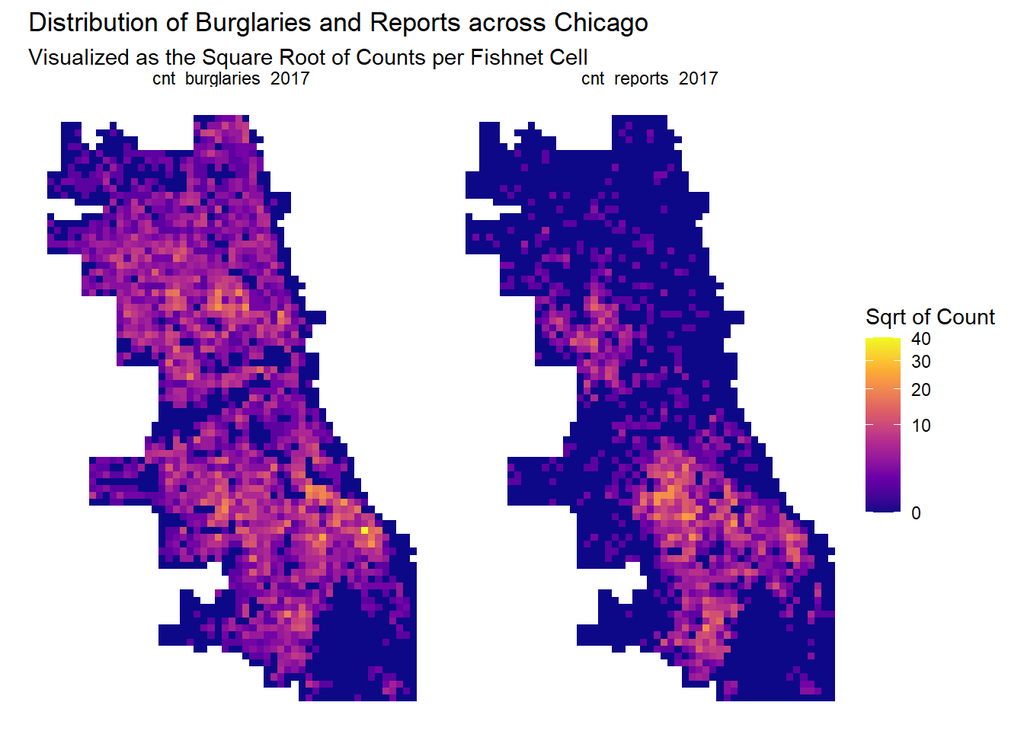

```r
# transform 2017 data
fishnet_2017_data_long <- fishnet_data %>%
  dplyr::select(-cnt_reports_2018) %>%
  pivot_longer(cols = c(cnt_burglaries_2017, cnt_reports_2017), names_to = "var", values_to = "value")

ggplot(fishnet_2017_data_long) +
  geom_sf(aes(fill = value), color = NA) +
  facet_wrap(~ var) +
  labs(title = "Distribution of Burglaries and Reports across Chicago",
       subtitle = "Visualized as the Square Root of Counts per Fishnet Cell") +
  scale_fill_viridis_c(option = "plasma", trans = "sqrt",
                       name = "Sqrt of Count") +
  theme_void()
```

While there seem to be matching areas of high counts in South Chicago, there is a notable lack of reports in North Chicago that do not match higher counts of burglaries in the same area.

```r
# summary statistics for burglaries
cat("Summary Statistics for Burglaries (2017):\n")
```

```
Summary Statistics for Burglaries (2017):
```

```r
summary(fishnet_data$cnt_burglaries_2017)
```

```
   Min. 1st Qu.  Median    Mean 3rd Qu.    Max.
  0.000   0.000   2.000   3.033   5.000  40.000
```

```r
cat("Percent of Cells with No Burglaries: ",
    round(sum(fishnet_data$cnt_burglaries_2017 == 0) / nrow(fishnet_data), 3)*100,
    "%\n\n",
    sep = "")
```

```
Percent of Cells with No Burglaries: 32.1%
```

```r
# summary statistics for reports 2017
cat("Summary Statistics for Vacant Building Reports (2017):\n")
```

```
Summary Statistics for Vacant Building Reports (2017):
```

```r
summary(fishnet_data$cnt_reports_2017)
```

```
   Min. 1st Qu.  Median    Mean 3rd Qu.    Max.
  0.000   0.000   0.000   1.485   1.000  24.000
```

```r
cat("Percent of Cells with No Vacant Building Reports: ",
    round(sum(fishnet_data$cnt_reports_2017 == 0) / nrow(fishnet_data), 3)*100,
    "%\n\n",
    sep = "")
```

```
Percent of Cells with No Vacant Building Reports: 64.4%
```

```r
# summary statistics for reports 2018
cat("Summary Statistics for Vacant Building Reports (2018):\n")
```

```
Summary Statistics for Vacant Building Reports (2018):
```

```r
summary(fishnet_data$cnt_reports_2018)
```

```
   Min. 1st Qu.  Median    Mean 3rd Qu.    Max.
  0.000   0.000   0.000   1.563   2.000  33.000
```

```r
cat("Percent of Cells with No Vacant Building Reports: ",
    round(sum(fishnet_data$cnt_reports_2018 == 0) / nrow(fishnet_data), 3)*100,
    "%\n\n",
    sep = "")
```

```
Percent of Cells with No Vacant Building Reports: 60.7%
```

There are approximately twice as many fishnet cells for both 2017 and 2018 that have no vacant building reports compared to those that have no burglaries, which is indicative of the wider spatial distribution of burglaries.

## Part 3: Spatial Features

### 3.1 - Kernel Density Estimation of Burglaries

Calculate a Kernel Density Estimation (KDE) baseline as a null hypothesis to demonstrate a scenario where burglaries occur in 2018 simply where they happened to occur in 2017. KDE spreads the value of a point (a single burglary) over a radius (1 kilometer) with the greatest share of the value close to the center of the point. By taking the mean value within a fishnet cell, we can get a distance-weighted, smoothed sense for how concentrated burglaries are in an area.

```r
# convert burglaries to ppp format for use with the spatstat package
burglaries_2017_ppp <- as.ppp(st_coordinates(burglaries_2017),
                         W = as.owin(st_bbox(chicagoBoundary)))

# calculate KDE values for burglary points
kde_burglaries <- density.ppp(burglaries_2017_ppp,
                              sigma = 1000,
                              edge = T)

# convert KDE values to a raster
kde_raster <- rast(kde_burglaries)

# extract mean KDE values from the spatial raster to the fishnet grid
fishnet_data <- fishnet_data %>%
  mutate(kde_value = terra::extract(kde_raster,
                                    vect(fishnet_data),
                                    fun = mean,
                                    na.rm = T)[,2])
```

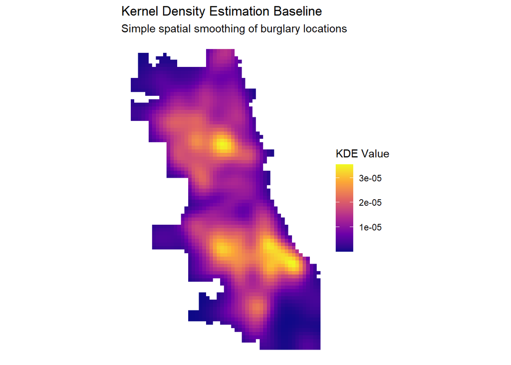

```r
ggplot() +
  geom_sf(data = fishnet_data, aes(fill = kde_value), color = NA) +
  scale_fill_viridis_c(name = "KDE Value",
                       option = "plasma") +
  labs(title = "Kernel Density Estimation Baseline",
       subtitle = "Simple spatial smoothing of burglary locations") +
  theme_void()
```

The KDE yields a map of burglary hot spots, where the influence of each burglary has been smoothed out and averaged. This provides a good sense of where generally burglaries happen, but this method also over-estimates where burglaries happen due to the indiscriminate nature of smoothing over a uniform 1km buffer.

### 3.2 - k-Nearest Neighbor to Reports

```r
# calculate coordinates of fishnet cells and the report locations
fishnet_coords <- st_coordinates(st_centroid(fishnet_data))
reports_coords <- st_coordinates(st_centroid(reports_2017_sf))

# calculate k nearest neighbors and distances
nn_result <- get.knnx(reports_coords, fishnet_coords, k = 3)

# join values to the fishnet
fishnet_data <- fishnet_data %>%
  mutate(knn_reports_2017 = rowMeans(nn_result$nn.dist))

summary(fishnet_data$knn_reports_2017)
```

```
    Min.  1st Qu.   Median     Mean  3rd Qu.     Max.
   3.622  290.991  613.944  788.606 1069.304 4773.328
```

The mean distance from the center of a fishnet cell to a report of a vacant building is approximately 790 meters. The value for k-nearest neighbor is an indicator of the average distance to the closest three reports of a vacant building. This is more descriptive than a simple count within a fishnet cell’s boundary since, for those that have no reports within them, there will still be a descriptive distance value to the nearest reports.

### 3.3 - Distance to Hot Spots (Local Moran’s I)

```r
calc_local_morans <- function(data, var, k) {
  coords <- st_coordinates(st_centroid(data))
  neighbors <- knn2nb(knearneigh(coords, k = k))
  weights <- nb2listw(neighbors, style = "W", zero.policy = T)

  local_moran <- localmoran(data[[var]], weights)

  mean_val <- mean(data[[var]], na.rm = T)

  data %>%
    mutate(local_i = local_moran[,1],
           p_value = local_moran[,5],
           is_sig = p_value < 0.05,
           moran_class = case_when(!is_sig ~ "Not Significant",
                                   local_i > 0 & .data[[var]] > mean_val ~ "High-High",
                                   local_i > 0 & .data[[var]] <= mean_val ~ "Low-Low",
                                   local_i < 0 & .data[[var]] > mean_val ~ "High-Low",
                                   local_i < 0 & .data[[var]] <= mean_val ~ "Low-High",
                                   TRUE ~ "Not Significant"))
}

# calculate local moran's I for vacant building reports in 2017
fishnet_data <- calc_local_morans(data = fishnet_data,
                                  var = "cnt_reports_2017",
                                  k = 5)
```

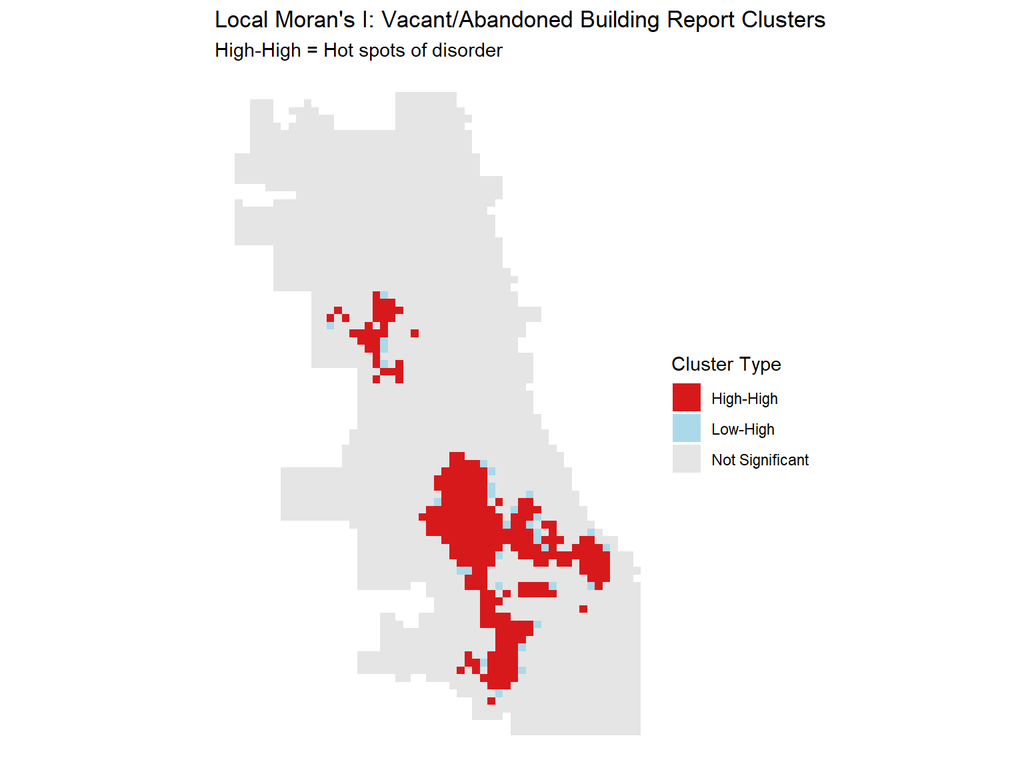

```r
# Visualize hot spots
ggplot() +
  geom_sf(
    data = fishnet_data,
    aes(fill = moran_class),
    color = NA
  ) +
  scale_fill_manual(
    values = c(
      "High-High" = "#d7191c",
      "High-Low" = "#fdae61",
      "Low-High" = "#abd9e9",
      "Low-Low" = "#2c7bb6",
      "Not Significant" = "gray90"
    ),
    name = "Cluster Type"
  ) +
  labs(
    title = "Local Moran's I: Vacant/Abandoned Building Report Clusters",
    subtitle = "High-High = Hot spots of disorder"
  ) +
  theme_void()
```

```r
hotspots <- fishnet_data %>%
  filter(moran_class == "High-High") %>%
  st_centroid()

# calculate distance from each cell to the nearest hot spot
if (nrow(hotspots) > 0) {
  fishnet_data <- fishnet_data %>%
    mutate(dist_to_hotspot = as.numeric(st_distance(st_centroid(fishnet_data),
                                                    hotspots %>%
                                                      st_union())))
  cat("Number of hot spot cells:", nrow(hotspots), "\n\n")
} else{
  fishnet_data <- fishnet_data %>%
    mutate(dist_to_hotspot = 0)
  cat("No significant hot spots found \n\n")
}
```

```
Number of hot spot cells: 278
```

```r
cat("Summary statistics of Distance to Hot Spot:\n")
```

```
Summary statistics of Distance to Hot Spot:
```

```r
summary(fishnet_data$dist_to_hotspot)
```

```
   Min. 1st Qu.  Median    Mean 3rd Qu.    Max.
      0    1000    3000    3863    6000   14577
```

## Part 4: Count Regression Models

### 4.1 - Join police districts for cross-validation later on

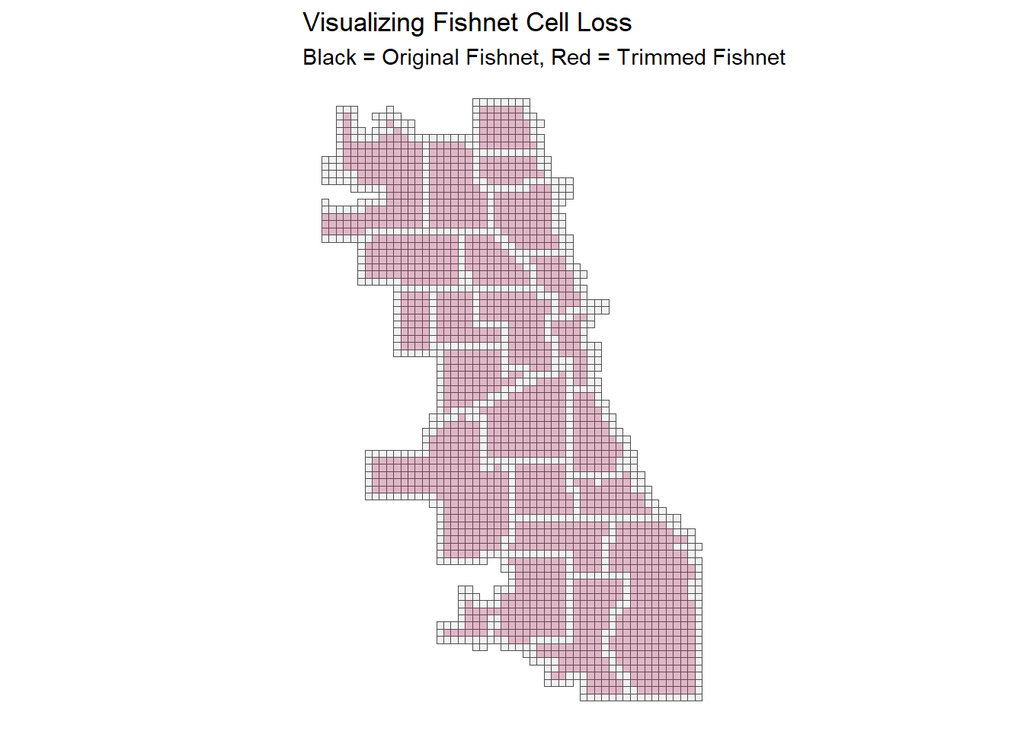

```r
fishnet_data_pd <- st_join(fishnet_data,
                        policeDistricts,
                        join = st_within,
                        left = T) %>%
  filter(!is.na(District))

ggplot() +
  geom_sf(data = fishnet_data, fill = "grey90", color = "grey30", alpha = 0.5) +
  geom_sf(data = fishnet_data_pd, fill = "maroon", color = NA, alpha = 0.3) +
  labs(title = "Visualizing Fishnet Cell Loss",
       subtitle = "Black = Original Fishnet, Red = Trimmed Fishnet") +
  theme_void()
```

```r
cat("Fishnet Cell Count Prior to Filtering:", nrow(fishnet_data), "\n\n")
```

```
Fishnet Cell Count Prior to Filtering: 2458
```

```r
cat("Fishnet Cell Count After Filtering:", nrow(fishnet_data_pd), "\n\n")
```

```
Fishnet Cell Count After Filtering: 1708
```

```r
cat("Cell Loss Percent: ",
    (1-round(nrow(fishnet_data_pd)/nrow(fishnet_data), 3))*100,
    "%",
    sep = "")
```

```
Cell Loss Percent: 30.5%
```

In order to accurately perform spatial cross-validation later in the analysis, we need to isolate only those fishnet cells that are entirely within each of Chicago’s police districts. This results in an approximately 30% loss in data, with 750 cells omitted.

### 4.2 - Poisson Regression

Poisson Regression is optimal for this modeling approach, since the dependent variable (burglaries) is a count variable.

```r
# extract variables to be used for modeling and remove spatial column
fishnet_model <- fishnet_data_pd %>%
  st_drop_geometry() %>%
  dplyr::select(fish_id,
                District,
                cnt_burglaries_2017,
                cnt_reports_2017,
                knn_reports_2017,
                dist_to_hotspot) %>%
  na.omit()
```

```r
# fit poisson regression model for 2017
model_poisson <- fishnet_model %>%
  glm(cnt_burglaries_2017 ~ cnt_reports_2017 + knn_reports_2017 + dist_to_hotspot,
      data = .,
      family = "poisson")

summary(model_poisson)
```

```
Call:
glm(formula = cnt_burglaries_2017 ~ cnt_reports_2017 + knn_reports_2017 +
    dist_to_hotspot, family = "poisson", data = .)

Coefficients:
                   Estimate Std. Error z value Pr(>|z|)
(Intercept)       1.679e+00  2.974e-02  56.455   <2e-16 ***
cnt_reports_2017  3.806e-02  3.501e-03  10.871   <2e-16 ***
knn_reports_2017 -9.788e-04  4.977e-05 -19.666   <2e-16 ***
dist_to_hotspot   6.984e-06  6.046e-06   1.155    0.248
---
Signif. codes:  0 '***' 0.001 '**' 0.01 '*' 0.05 '.' 0.1 ' ' 1

(Dispersion parameter for poisson family taken to be 1)

    Null deviance: 6708.8  on 1707  degrees of freedom
Residual deviance: 5229.5  on 1704  degrees of freedom
AIC: 9296.8

Number of Fisher Scoring iterations: 6
```

### 6.2 - Check for Overdispersion

```r
dispersion <- sum(residuals(model_poisson,
                            type = "pearson")^2) / model_poisson$df.residual
cat("Dispersion Parameter:", round(dispersion, 2), "\n")
```

```
Dispersion Parameter: 3.34
```

```r
cat("Rule of Thumb: >1.5 typically suggests overdispersion \n")
```

```
Rule of Thumb: >1.5 typically suggests overdispersion
```

```r
if (dispersion > 1.5) {
  cat("⚠ Overdispersion detected! Consider Negative Binomial model.\n")
} else {
  cat("✓ Dispersion looks okay for Poisson model.\n")
}
```

```
⚠ Overdispersion detected! Consider Negative Binomial model.
```

This model violates the assumption that the mean of the dependent variable is equal to its variance, which is typically not true for crime datasets. A negative binomial model should be calculated to see if it predicts better.

### 6.3 - Negative Binomial Regression

```r
# fit a negative binomial model
model_nb <- fishnet_data_pd %>%
  glm.nb(cnt_burglaries_2017 ~ cnt_reports_2017 + knn_reports_2017 + dist_to_hotspot,
         data = .)

summary(model_nb)
```

```
Call:
glm.nb(formula = cnt_burglaries_2017 ~ cnt_reports_2017 + knn_reports_2017 +
    dist_to_hotspot, data = ., init.theta = 1.469874947, link = log)

Coefficients:
                   Estimate Std. Error z value Pr(>|z|)
(Intercept)       1.626e+00  5.547e-02  29.323  < 2e-16 ***
cnt_reports_2017  4.536e-02  8.117e-03   5.589 2.29e-08 ***
knn_reports_2017 -9.871e-04  7.590e-05 -13.005  < 2e-16 ***
dist_to_hotspot   2.042e-05  1.029e-05   1.984   0.0473 *
---
Signif. codes:  0 '***' 0.001 '**' 0.01 '*' 0.05 '.' 0.1 ' ' 1

(Dispersion parameter for Negative Binomial(1.4699) family taken to be 1)

    Null deviance: 2419.3  on 1707  degrees of freedom
Residual deviance: 1962.7  on 1704  degrees of freedom
AIC: 7772.2

Number of Fisher Scoring iterations: 1

              Theta:  1.4699
          Std. Err.:  0.0839

 2 x log-likelihood:  -7762.2070
```

```r
# compare the AIC scores of both models (lower is better)
cat("\n\nModel Comparison:\n",
    "Poisson AIC:", round(AIC(model_poisson), 1), "\n",
    "Negative Binomial AIC:", round(AIC(model_nb), 1))
```

```
Model Comparison:
 Poisson AIC: 9296.8
 Negative Binomial AIC: 7772.2
```

The negative binomial model has an improved AIC value, and while its coefficients follow the same sign pattern as before where the sign for distance to the nearest hot spot doesn’t make sense, it is now significant (p < 0.05) with a standard error that is slightly improved at 50.4% of the coefficient value. This tells us that the negative binomial model is better at modeling burglary counts since it introduces a dispersion parameter that relaxes the assumption of the poisson regression that mean = variance.

## Part 5: Spatial Cross-Validation (2017)

```r
districts <- unique(fishnet_model$District)
cv_results <- tibble()

for (i in seq_along(districts)) {
  test_district <- districts[i]

  # split into training and testing data
  train_data <- fishnet_model %>% filter(District != test_district)
  test_data <- fishnet_model %>% filter(District == test_district)

  # fit model on training data
  model_cv <- fishnet_model %>%
    glm.nb(cnt_burglaries_2017 ~
           cnt_reports_2017 +
           knn_reports_2017 +
           dist_to_hotspot,
           data = .)

  # predict on test data
  test_data <- test_data %>%
    mutate(pred = predict(model_cv, test_data, type = "response"))

  # calculate metrics
  mae <- mean(abs(test_data$cnt_burglaries_2017 - test_data$pred))
  rmse <- sqrt(mean((test_data$cnt_burglaries_2017 - test_data$pred)^2))

  # store results
  cv_results <- bind_rows(cv_results,
                          tibble(fold = i,
                                 test_district = test_district,
                                 n_test = nrow(test_data),
                                 mae = mae,
                                 rmse = rmse))
}
```

```r
# view results of the spatial cross-validation
cv_results %>%
  arrange(desc(mae)) %>%
  kable(digits = 2,
       caption = "LOGO CV Results by Police District") %>%
  kable_styling(bootstrap_options = c("striped", "hover"))
```

LOGO CV Results by Police District

| fold | test_district | n_test | mae | rmse |
| --- | --- | --- | --- | --- |
| 7 | 3 | 43 | 5.45 | 7.12 |
| 12 | 12 | 73 | 3.58 | 4.99 |
| 6 | 7 | 52 | 3.15 | 3.78 |
| 17 | 14 | 46 | 3.13 | 4.58 |
| 4 | 6 | 63 | 3.01 | 4.21 |
| 14 | 11 | 43 | 3.01 | 3.43 |
| 8 | 2 | 56 | 2.72 | 3.39 |
| 16 | 25 | 85 | 2.69 | 3.73 |
| 2 | 4 | 235 | 2.54 | 3.69 |
| 1 | 5 | 98 | 2.44 | 2.84 |
| 15 | 18 | 30 | 2.42 | 4.08 |
| 5 | 8 | 197 | 2.42 | 3.38 |
| 9 | 9 | 107 | 2.42 | 2.85 |
| 11 | 1 | 28 | 2.37 | 3.01 |
| 18 | 19 | 63 | 2.30 | 3.03 |
| 13 | 15 | 32 | 2.24 | 2.82 |
| 10 | 10 | 63 | 2.11 | 2.76 |
| 3 | 22 | 112 | 2.06 | 2.58 |
| 22 | 24 | 41 | 1.99 | 2.80 |
| 21 | 20 | 30 | 1.73 | 2.10 |
| 20 | 17 | 82 | 1.70 | 2.11 |
| 19 | 16 | 129 | 1.66 | 1.97 |

## Part 6: Model Evaluation

### 6.1 - Generate Final Predictions

```r
# fit final model on all data
final_model <- fishnet_model %>%
  glm.nb(cnt_burglaries_2017 ~ cnt_reports_2017 + knn_reports_2017 + dist_to_hotspot,
         data = .)

# add predictions to the fishnet
fishnet_data_pd <- fishnet_data_pd %>%
  mutate(pred_nb = predict(final_model, fishnet_model, type = "response")[match(fish_id, fishnet_model$fish_id)])

# add KDE predictions (normalized to the same scale as counts)
kde_sum <- sum(fishnet_data_pd$kde_value, na.rm = T)
count_sum <- sum(fishnet_data_pd$cnt_burglaries_2017, na.rm = T)
fishnet_data_pd <- fishnet_data_pd %>% mutate(pred_kde = (kde_value/kde_sum) * count_sum)
```

```r
# create a summary table of the model's coefficients
model_summary <- broom::tidy(final_model, exponentiate = TRUE) %>%
  mutate(
    across(where(is.numeric), ~round(., 3))
  )

model_summary %>%
  kable(
    caption = "Final Negative Binomial Model Coefficients (Exponentiated)",
    col.names = c("Variable", "Rate Ratio", "Std. Error", "Z", "P-Value")
  ) %>%
  kable_styling(bootstrap_options = c("striped", "hover")) %>%
  footnote(
    general = "Rate ratios > 1 indicate positive association with burglary counts."
  )
```

Final Negative Binomial Model Coefficients (Exponentiated)

| Variable | Rate Ratio | Std. Error | Z | P-Value |
| --- | --- | --- | --- | --- |
| (Intercept) | 5.086 | 0.055 | 29.323 | 0.000 |
| cnt_reports_2017 | 1.046 | 0.008 | 5.589 | 0.000 |
| knn_reports_2017 | 0.999 | 0.000 | -13.005 | 0.000 |
| dist_to_hotspot | 1.000 | 0.000 | 1.984 | 0.047 |

Note:  
Rate ratios > 1 indicate positive association with burglary counts.

The final model coefficients, when exponentiated, indicate that within a fishnet cell an increase of one report of an abandoned/vacant building results in a 4.6% increase in burglaries, a one unit increase in mean distance from the centroid of a fishnet cell to the nearest three reports of an abandoned/vacant building results in a 0.1% decrease in burglaries, and distance to the nearest hot spot has no effect on the number of burglaries within that fishnet cell.

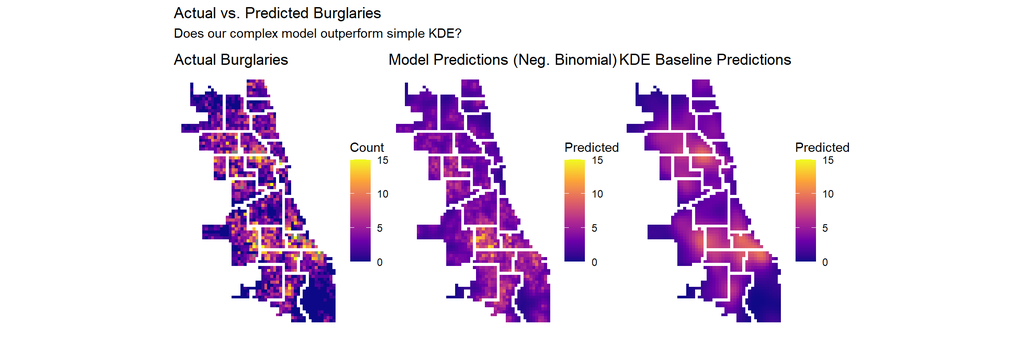

```r
# Create three maps
p1 <- ggplot() +
  geom_sf(data = fishnet_data_pd, aes(fill = cnt_burglaries_2017), color = NA) +
  scale_fill_viridis_c(name = "Count", option = "plasma", limits = c(0, 15)) +
  labs(title = "Actual Burglaries") +
  theme_void()

p2 <- ggplot() +
  geom_sf(data = fishnet_data_pd, aes(fill = pred_nb), color = NA) +
  scale_fill_viridis_c(name = "Predicted", option = "plasma", limits = c(0, 15)) +
  labs(title = "Model Predictions (Neg. Binomial)") +
  theme_void()

p3 <- ggplot() +
  geom_sf(data = fishnet_data_pd, aes(fill = pred_kde), color = NA) +
  scale_fill_viridis_c(name = "Predicted", option = "plasma", limits = c(0, 15)) +
  labs(title = "KDE Baseline Predictions") +
  theme_void()

p1 + p2 + p3 +
  plot_annotation(
    title = "Actual vs. Predicted Burglaries",
    subtitle = "Does our complex model outperform simple KDE?"
  )
```

```r
# Calculate performance metrics
comparison <- fishnet_data_pd %>%
  st_drop_geometry() %>%
  filter(!is.na(pred_nb), !is.na(pred_kde)) %>%
  summarize(
    model_mae = mean(abs(cnt_burglaries_2017 - pred_nb)),
    model_rmse = sqrt(mean((cnt_burglaries_2017 - pred_nb)^2)),
    kde_mae = mean(abs(cnt_burglaries_2017 - pred_kde)),
    kde_rmse = sqrt(mean((cnt_burglaries_2017 - pred_kde)^2))
  )

comparison %>%
  pivot_longer(everything(), names_to = "metric", values_to = "value") %>%
  separate(metric, into = c("approach", "metric"), sep = "_") %>%
  pivot_wider(names_from = metric, values_from = value) %>%
  kable(
    digits = 2,
    caption = "Model Performance Comparison"
  ) %>%
  kable_styling(bootstrap_options = c("striped", "hover"))
```

Model Performance Comparison

| approach | mae | rmse |
| --- | --- | --- |
| model | 2.51 | 3.46 |
| kde | 2.06 | 2.95 |

The more complex negative binomial model does not outperform a simple KDE baseline, with Mean Absolute Error (MAE) and Root Mean Squared Error (RMSE) values both less for the KDE baseline compared to the NB model. This indicates that the added complexity of the NB model might not be worth it when based off of 311 calls that report Vacant/Abandoned Buildings.

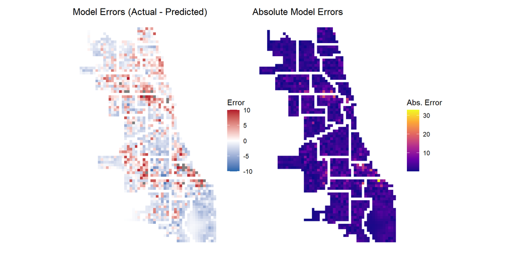

```r
# Calculate errors
fishnet_data_pd <- fishnet_data_pd %>%
  mutate(
    error_nb = cnt_burglaries_2017 - pred_nb,
    error_kde = cnt_burglaries_2017 - pred_kde,
    abs_error_nb = abs(error_nb),
    abs_error_kde = abs(error_kde)
  )

# Map errors
p1 <- ggplot() +
  geom_sf(data = fishnet_data_pd, aes(fill = error_nb), color = NA) +
  scale_fill_gradient2(
    name = "Error",
    low = "#2166ac", mid = "white", high = "#b2182b",
    midpoint = 0,
    limits = c(-10, 10)
  ) +
  labs(title = "Model Errors (Actual - Predicted)") +
  theme_void()

p2 <- ggplot() +
  geom_sf(data = fishnet_data_pd, aes(fill = abs_error_nb), color = NA) +
  scale_fill_viridis_c(name = "Abs. Error", option = "plasma") +
  labs(title = "Absolute Model Errors") +
  theme_void()

p1 + p2
```

The model coefficients and this analysis of prediction accuracy indicate that while this modeling approach could be improved upon with additional/more complete data to predict burglary distribution better, this model in its current form should not be used to predict for other years.